# Regresión lineal simple

Alex E. Pérez Tatamués

3 de julio de 2015

### Introducción

El presente documento tiene como objetivo presentar la forma de como generar un **reporte** automático utilizano:

- R
- Markdown
  - **Rmarkdown**

### Descripción información

Iniciamos cargando el archivo que contiene las varibles a utilizar, el paquete *readxl* permite leer archivos desde excel sin la necesidad de instalar complementos.

```r
options(warn=-1)
library(readxl)
data <- read_excel("data_rls_uti.xlsx",sheet=1,na="")
str(data)
```

```
## Classes 'tbl_df', 'tbl' and 'data.frame':    40 obs. of  2 variables:
##  $ Utilidad: num  6017 8049 8551 6720 7391 ...
##  $ Ventas  : num  13270 17127 17814 16000 18026 ...
```

Analizando la información disponemos de 40 observaciones de 2 variables. Se requiere explicar la varible Utilidad en función del regresor Ventas. En lugar de utilizar la función `View(data)` para vizualizar el conjunto de datos empleamos la función `datatable()` del paquete `DT()`, esta función permite crear un **HTML widget** para mostrar data rectangular:

- matrix
- data frame

en archivos:

- Rmarkdown
- Rsweave
- Shiny apps, etc

En nuestro caso tenemos lo siguiente:

```r
library(DT)
datatable(data)
```

|  | Utilidad | Ventas |
| --- | --- | --- |
| 1 | 6017 | 13270 |
| 2 | 8049 | 17127 |
| 3 | 8551 | 17814 |
| 4 | 6720 | 16000 |
| 5 | 7391 | 18026 |
| 6 | 8045 | 17877 |
| 7 | 5814 | 13214 |
| 8 | 4954 | 10321 |
| 9 | 5564 | 12365 |
| 10 | 7160 | 15235 |

[output cut: 30 more lines]

### Modelo de regresión lineal simple

Ajustando un modelo de regresión para las variables Utilidad y Ventas utilizando la función `lm()` obtenemos el siguiente resultado:

```r
reg <- lm(Utilidad~Ventas, data)
summary(reg)
```

```
##
## Call:
## lm(formula = Utilidad ~ Ventas, data = data)
##
## Residuals:
##     Min      1Q  Median      3Q     Max
## -676.35 -302.04   42.59  303.67  612.49
##
## Coefficients:
##              Estimate Std. Error t value Pr(>|t|)
## (Intercept) 137.08270  282.69543   0.485    0.631
## Ventas        0.43994    0.01859  23.663   <2e-16 ***
## ---
## Signif. codes:  0 '***' 0.001 '**' 0.01 '*' 0.05 '.' 0.1 ' ' 1
##
## Residual standard error: 367.4 on 38 degrees of freedom
## Multiple R-squared:  0.9364, Adjusted R-squared:  0.9348
## F-statistic: 559.9 on 1 and 38 DF,  p-value: < 2.2e-16
```

es decir nuestro modelo resultante estaría dado por la expresión $\hat{Ut} = 137.0826988 + 0.4399352 \hat{Ve}$

### Interpretación

**Interpretación modelo:** *Si Ventas se incrementa en una unidad, entonces Utilidad aumenta en promedio 0.4399352 unidades.*

**Interpretación $R^2$:** *El modelo de regresión lineal obtenido explica el 93.644770256961 % de la variabilidad total.*

### Pruebas de hipótesis

Analizando **lOS VALORES DE T** tenemos los siguientes resultados:

Para $: \beta_1$ es:

```r
summary(reg)$coefficients[[5]]
```

```
## [1] 0.484913
```

Como $t=0.484913$ es menor que $t_{38}(\frac{\alpha}{2})= 1.6859545$ no rechazo $H_0: \beta_1=0$.

Para $: \beta_2$ es:

```r
summary(reg)$coefficients[[6]]
```

```
## [1] 23.6629
```

Como $t=23.6628982$ es mayor que $t_{38}(\frac{\alpha}{2})= 1.6859545$ rechazo $H_0: \beta_2=0$.

### Análisis de varianza

Realizando la tabla **ANOVA** tenemos los siguientes resultados:

```r
anova <- aov(reg)
summary(anova)[[1]]
```

```
##             Df   Sum Sq  Mean Sq F value    Pr(>F)
## Ventas       1 75578286 75578286  559.93 < 2.2e-16 ***
## Residuals   38  5129142   134977
## ---
## Signif. codes:  0 '***' 0.001 '**' 0.01 '*' 0.05 '.' 0.1 ' ' 1
```

Como $F=559.9327505$ es mayor que $F_{1,38}(\frac{\alpha}{2})= 4.0981717$ rechazo $H_0: \beta_2=0$.

### Intervalos de confianza

```r
confint(reg,level = 0.95)
```

```
##                    2.5 %      97.5 %
## (Intercept) -435.2042893 709.3696869
## Ventas         0.4022981   0.4775722
```

### Gráficos residuales

```r
residuo <- reg[["residuals"]]
prediccion <- reg[["fitted.values"]]
data2 <- data.frame(data, prediccion,residuo)
datatable(data2,filter="top", options = list(
  searching = TRUE,
  pageLength = 5,
 lengthMenu = c(5, 10, 15)
 ))
```

|  | Utilidad | Ventas | prediccion | residuo |
| --- | --- | --- | --- | --- |
| 1 | 6017 | 13270 | 5975.02243284767 | 41.977567152329 |
| 2 | 8049 | 17127 | 7671.85239172628 | 377.147608273715 |
| 3 | 8551 | 17814 | 7974.08785497483 | 576.912145025173 |
| 4 | 6720 | 16000 | 7176.04545274361 | -456.045452743607 |
| 5 | 7391 | 18026 | 8067.35411146491 | -676.354111464915 |
| 6 | 8045 | 17877 | 8001.80377081858 | 43.1962291814205 |
| 7 | 5814 | 13214 | 5950.38606320878 | -136.386063208778 |
| 8 | 4954 | 10321 | 4677.65361025678 | 276.346389743218 |
| 9 | 5564 | 12365 | 5576.88110207631 | -12.881102076305 |
| 10 | 7160 | 15235 | 6839.49504606947 | 320.50495393053 |

[output cut: 30 more lines]

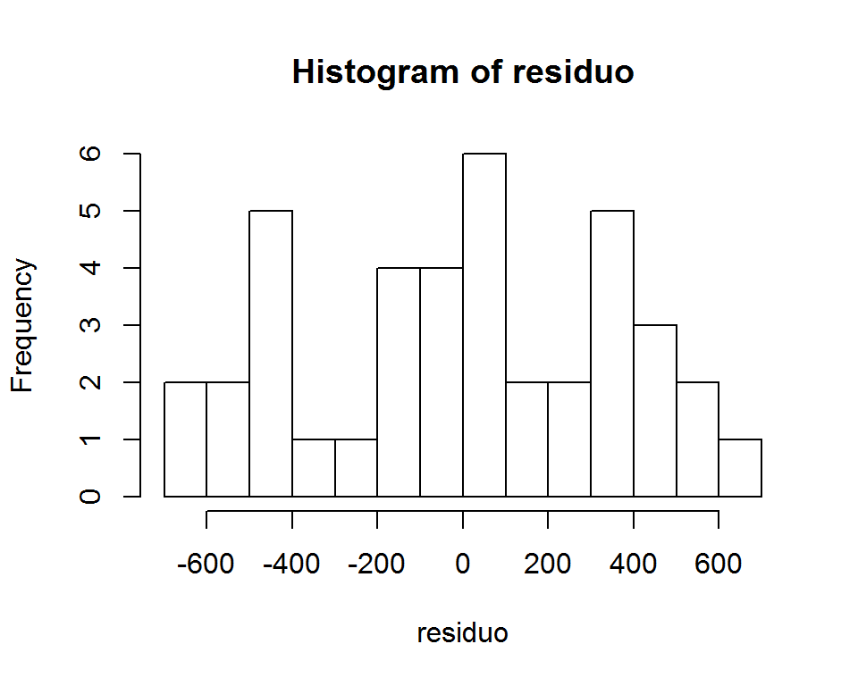

```r
hist(residuo,15)
```

```r
mean(residuo)
```

```
## [1] -8.14071e-15
```

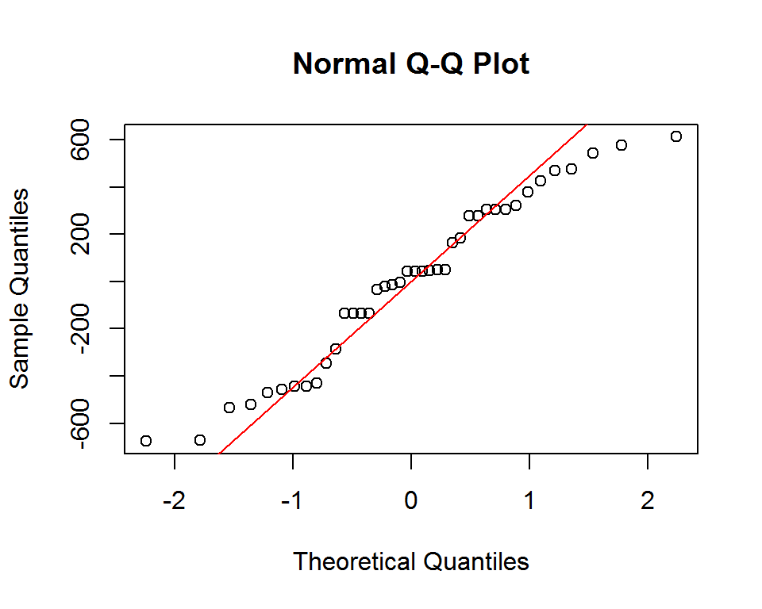

```r
qqnorm(residuo)
qqline(residuo,col="red")
```

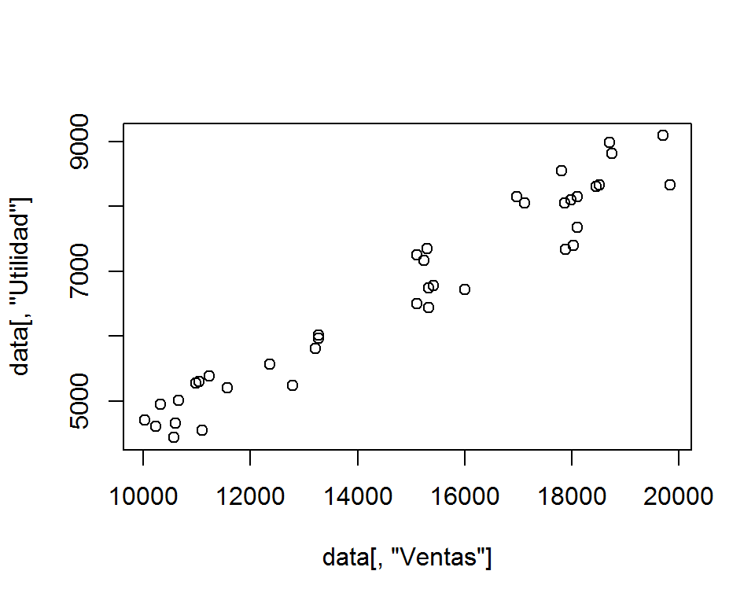

```r
plot(data[,"Ventas"],data[,"Utilidad"])
```

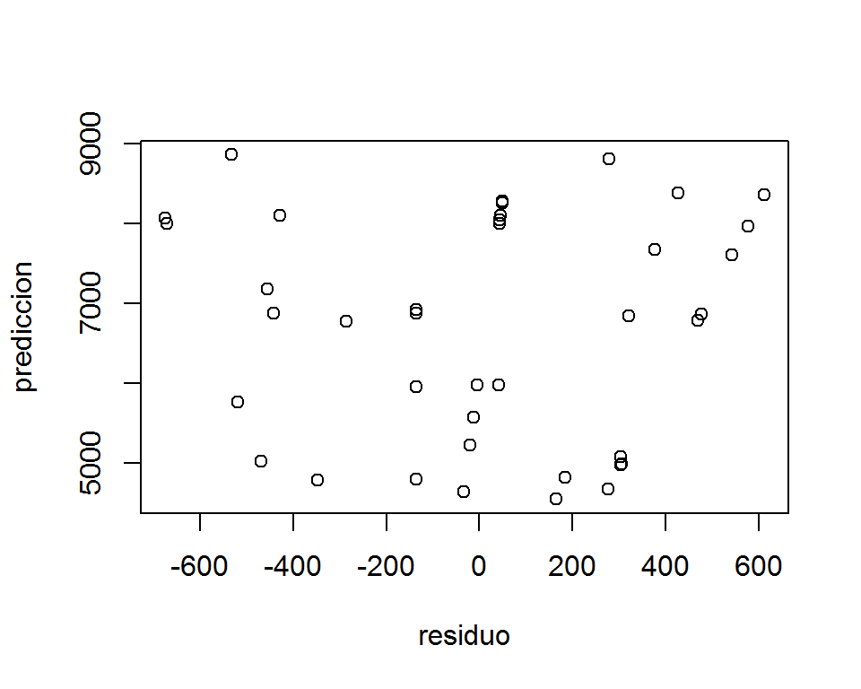

```r
plot(residuo,prediccion)
```

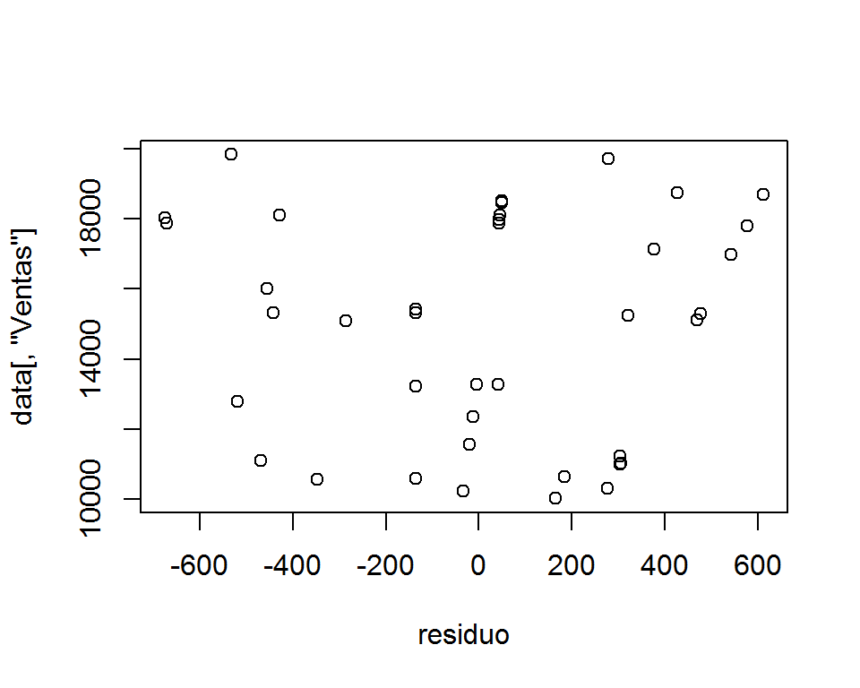

```r
plot(residuo,data[,"Ventas"])
```